# 回帰モデルの発展：分散分析と回帰分析の融合

藤野秀則

初稿日:“2024-10-08” 更新日:2025-07-08

これまでは**回帰分析説明変数・目的変数ともに連続変数**の場合に用い，**分散分析は説明変数がカテゴリカル変数，目的変数が連続変数**の場合に用いるとして，それぞれ別々に説明してきた．また，分散分析では交互作用を含めたモデルについて触れたが，回帰分析ではそれは触れていない，などの違いもあった．

しかし実際には分散分析は回帰分析の一種であり，回帰分析と分散分析は同じ枠組みの中で説明・実施できる． 今回はそれらについて説明する．

# 1 ダミー変数を用いた回帰分析

先にも述べているように，一般に**回帰分析説明変数・目的変数ともに連続変数**，**分散分析は説明変数がカテゴリカル変数，目的変数が連続変数**，というように使い分けられている．

しかし実際には，**0，1の2値を取るダミー変数**と呼ばれる変数を導入し，カテゴリカル変数の各水準をダミー変数として表現することによってことによって，回帰分析においても説明変数にカテゴリカル変数を含めることができる．

例1 性別（男・女）のような2つの水準を持つカテゴリカル変数を説明変数として回帰分析を行う場合，以下のように1つのダミー変数を導入することによって，回帰分析を行うことができる．

|  | $X$ |
| --- | --- |
| 男 | 0 |
| 女 | 1 |

例2 A,B,Cという3つの水準を持つカテゴリカル変数を説明変数として回帰分析を行う場合，以下のように2つのダミー変数を導入することによって．

|  | $X_1$ | $X_2$ |
| --- | --- | --- |
| A | 0 | 0 |
| B | 1 | 0 |
| C | 0 | 1 |

このように，$n$個の水準を持つカテゴリカル変数を説明変数に含めて回帰分析を行う場合，$n-1$個のダミー変数を導入することによって，回帰分析を行うことができる．

## 1.1 2水準をもつカテゴリカル変数を含んだ回帰分析

このデータは，ある企業の従業員250人のデータである．データは，性別（0:女性，1:男性）, その企業での就労期間（連続変数），過去1年間の月当たりの平均残業時間（連続変数），その企業の従業員のの過去1年間の平均月収（単位：万円）を記録したものである．このデータをもとに，平均月収を予測する式を作れ．

この例のデータの場合には，性別をダミー変数として導入することになる．今回のデータの場合には既に性別は0,1でコード化されているので，読み込んだデータをそのまま`lm()`関数に渡すことで回帰分析を行うことができる．

```r
data <- read.csv("./practice/example_11_Dammy.csv")
fit_gender <- lm(平均月収 ~ 性別 + 就労期間 + 残業時間, data = data)
summary(fit_gender)
```

```
##
## Call:
## lm(formula = 平均月収 ~ 性別 + 就労期間 + 残業時間,
##     data = data)
##
## Residuals:
##     Min      1Q  Median      3Q     Max
## -15.850  -2.272   1.201   2.777  11.009
##
## Coefficients:
##             Estimate Std. Error t value Pr(>|t|)
## (Intercept) 19.25094    0.67525  28.509   <2e-16 ***
## 性別         1.59801    0.78703   2.030   0.0434 *
## 就労期間     0.88218    0.02295  38.442   <2e-16 ***
## 残業時間     0.28777    0.02944   9.774   <2e-16 ***
## ---
## Signif. codes:  0 '***' 0.001 '**' 0.01 '*' 0.05 '.' 0.1 ' ' 1
##
## Residual standard error: 4.13 on 246 degrees of freedom
## Multiple R-squared:  0.8907, Adjusted R-squared:  0.8894
## F-statistic: 668.3 on 3 and 246 DF,  p-value: < 2.2e-16
```

この結果から，以下のような予測式を立てることができる．

$$平均月収= 19.25+
1.598 \times 性別 +
0.882 \times 就労期間 +
0.288 \times 残業時間$$

つまり，性別が1，すなわち男性の場合には平均月収が15980円高くなる，就労期間が1年長くなると8820円高くなる，残業時間が1時間伸びると2880円高くなる，ということが分かる． また，いずれの回帰係数も有意であり，性別，就労期間，残業時間は平均月収に対して有意な影響を与えていることが分かる．

**カテゴリカル変数を含んだ回帰分析のイメージ**

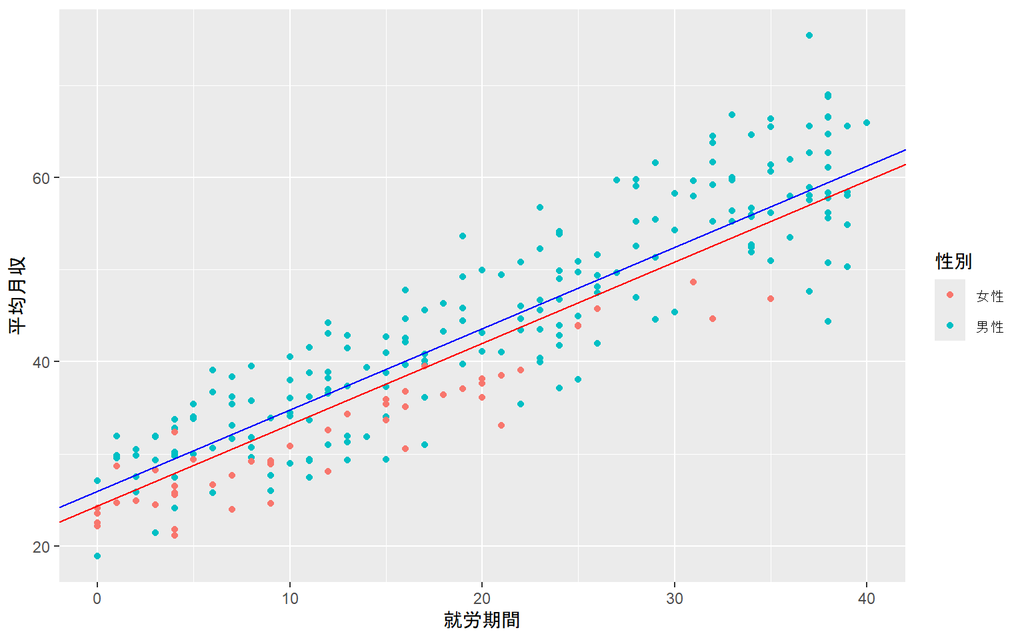

```r
library(ggplot2)
data$性別 <- as.factor(data$性別)
ggplot(data, aes(x = 就労期間, y = 平均月収,color=性別)) +
  geom_point() + #geom_smooth(method = "lm", se = FALSE) +
  #scale_x_continuous(limits=c(0,40), breaks = seq(0, 40, 5)) +
  #scale_y_continuous(limits=c(20,70),breaks = seq(0, 70, 20)) +
  geom_abline(intercept = coef(fit_gender)[1]+coef(fit_gender)[4]*mean(data$残業時間),
              slope = coef(fit_gender)[3], color = "red")+
  geom_abline(intercept = coef(fit_gender)[1]+coef(fit_gender)[2]+coef(fit_gender)[4]*mean(data$残業時間),
              slope = coef(fit_gender)[3], color = "blue") +
  scale_color_discrete(label=c("女性", "男性"))
```

男性と女性とで傾きは同じであるが切片は異なっている．

つまりカテゴリカル変数を導入した回帰分析とは，**カテゴリカル変数の各水準によって切片が異なっているが，傾きは同じである**という仮定を置いた回帰分析ということである（注1）．

この仮定を置かなかった場合（つまりカテゴリカル変数を説明変数に加えなかった場合）には，以下の黒色の直線となる．

```r
fit_no_gender <- lm(平均月収 ~ 就労期間 + 残業時間, data = data)
summary(fit_no_gender)
```

```
##
## Call:
## lm(formula = 平均月収 ~ 就労期間 + 残業時間, data = data)
##
## Residuals:
##      Min       1Q   Median       3Q      Max
## -15.8148  -2.3465   0.5404   3.0000  10.5355
##
## Coefficients:
##             Estimate Std. Error t value Pr(>|t|)
## (Intercept) 19.78798    0.62521   31.65   <2e-16 ***
## 就労期間     0.89330    0.02243   39.84   <2e-16 ***
## 残業時間     0.31747    0.02571   12.35   <2e-16 ***
## ---
## Signif. codes:  0 '***' 0.001 '**' 0.01 '*' 0.05 '.' 0.1 ' ' 1
##
## Residual standard error: 4.156 on 247 degrees of freedom
## Multiple R-squared:  0.8889, Adjusted R-squared:  0.888
## F-statistic: 987.9 on 2 and 247 DF,  p-value: < 2.2e-16
```

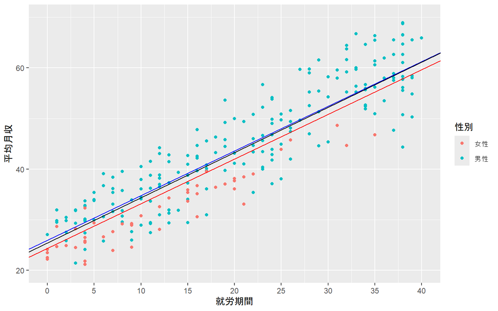

```r
ggplot(data, aes(x = 就労期間, y = 平均月収)) +
  geom_point(aes(color=性別)) +   scale_color_discrete(label=c("女性", "男性")) +
  scale_x_continuous(limits=c(0,40), breaks = seq(0, 40, 5)) +
  scale_y_continuous(limits=c(20,70),breaks = seq(0, 70, 20)) +
  geom_abline(intercept = coef(fit_gender)[1]+coef(fit_gender)[4]*mean(data$残業時間),
              slope = coef(fit_gender)[3], color = "red")+
  geom_abline(intercept = coef(fit_gender)[1]+coef(fit_gender)[2]+coef(fit_gender)[4]*mean(data$残業時間),
              slope = coef(fit_gender)[3], color = "blue") +
  geom_abline(intercept = coef(fit_no_gender)[1]+coef(fit_no_gender)[3]*mean(data$残業時間),
              slope = coef(fit_no_gender)[2], color = "black")
```

つまり，男女別を考慮せずに分析した場合と，男女別を考慮した場合とでは就労期間の平均月収に対する影響力が異なっている，ということである． また，自由度調整済み決定係数を見てみると，男女別を考慮した場合の方が高いことから，男女別を考慮した方がより適切なモデルであると言える．

さらに，以下の`anova()`関数を用いることによって，この2つのモデルに有意な差があるかどうかを検定することもできる．

```r
anova(fit_gender, fit_no_gender)
```

```
## Analysis of Variance Table
##
## Model 1: 平均月収 ~ 性別 + 就労期間 + 残業時間
## Model 2: 平均月収 ~ 就労期間 + 残業時間
##   Res.Df    RSS Df Sum of Sq      F  Pr(>F)
## 1    246 4196.9
## 2    247 4267.3 -1   -70.335 4.1226 0.04339 *
## ---
## Signif. codes:  0 '***' 0.001 '**' 0.01 '*' 0.05 '.' 0.1 ' ' 1
```

このように，カテゴリカル変数を導入して，グループごとに切片の値が異なっているという前提で分析を行うことによって，モデル全体の予測力が向上することがある．もちろん，導入しても大して予測力の向上が見られない（カテゴリカル変数が有意にならない）のであれば，カテゴリカル変数を導入する必要はない．

注1：切片も傾きも異なるという仮定もあり得て，それが次に説明する交互作用項を含んだモデルである参考．

**分散分析との相違点**

回帰分析でダミー変数を導入するのと同様に，分散分析で連続変数を導入することもできる． たとえば，上記の例を分散分析で行うと以下の通りとなる（タイプ2の分散分析になることに注意！）．

```r
library(car)
data$性別 <- as.factor(data$性別)
Res_aov <- aov(平均月収 ~ 性別 + 就労期間 + 残業時間, data = data)
Anova(Res_aov, type = 2)
```

```
## Anova Table (Type II tests)
##
## Response: 平均月収
##            Sum Sq  Df   F value  Pr(>F)
## 性別         70.3   1    4.1226 0.04339 *
## 就労期間  25212.5   1 1477.8193 < 2e-16 ***
## 残業時間   1629.7   1   95.5250 < 2e-16 ***
## Residuals  4196.9 246
## ---
## Signif. codes:  0 '***' 0.001 '**' 0.01 '*' 0.05 '.' 0.1 ' ' 1
```

P値が先ほどの回帰分析の結果と同じであることが確認できる． すなわち，就労時間や残業時間を統制したうえで，性別の影響が平均月収に対して有意であることが分かる．

このように，回帰分析の結果と分散分析の結果は一致する．ただし，分散分析の場合には実際にカテゴリ間にどの程度の差があるのかまでは分からない(参考)．

**参考**

以下のように単純に男女に分けてそれぞれの平均を求めるという方法は誤りである．このような単純な平均の差は男女間での就労期間の差や残業時間の差を考慮していないため，男女間の平均月収の差を正確に評価することができない．

```r
aggregate(平均月収 ~ 性別, data = data, mean)
```

```
##   性別 平均月収
## 1    0 31.79204
## 2    1 44.96465
```

## 1.2 多水準をもつカテゴリカル変数を含んだ回帰分析

先ほどは性別(2水準)を含んだ回帰分析を行ったが，3水準以上のカテゴリカル変数を含んだ回帰分析を行う場合には，ダミー変数を導入する際には，$\text{その水準数}-1$個のダミー変数を導入する必要がある．

このデータは先ほどの従業員の月収に関するデータに各サンプルの学歴(0:高卒，1:大卒，2:院卒)も加わえたデータである．性別，学歴，就労期間，残業時間を説明変数として，平均月収を予測する式を作れ．

この例のデータの場合には，性別に加えて学歴をダミー変数として導入することになる．学歴は3水準を持つカテゴリカル変数であるため，2つのダミー変数を導入することになる． ただ，Rではわざわざ手作業でダミー変数を用意する必要はない．**Rでは，カテゴリカル変数のクラスを`factor`型に変換しておくことによって，自動的にダミー変数が作成される**．

`factor`型への変換はデータを読み込んだ際に`as.factor()`関数を用いて予め行っておく．

```r
data <- read.csv("./practice/example_11_Dammy2.csv")
data$学歴<- as.factor(data$学歴)
fit_edu <- lm(平均月収 ~ 性別 + 学歴 + 就労期間 + 残業時間, data = data)
summary(fit_edu)
```

```
##
## Call:
## lm(formula = 平均月収 ~ 性別 + 学歴 + 就労期間 +
##     残業時間, data = data)
##
## Residuals:
##     Min      1Q  Median      3Q     Max
## -9.2152 -0.8604 -0.0963  0.8003  7.8375
##
## Coefficients:
##             Estimate Std. Error t value Pr(>|t|)
## (Intercept) 14.71822    0.44616  32.988   <2e-16 ***
## 性別        -0.55115    0.42336  -1.302    0.194
## 学歴1        5.15709    0.37243  13.847   <2e-16 ***
## 学歴2        9.74741    0.34822  27.992   <2e-16 ***
## 就労期間     0.88163    0.01117  78.919   <2e-16 ***
## 残業時間     0.29110    0.01433  20.320   <2e-16 ***
## ---
## Signif. codes:  0 '***' 0.001 '**' 0.01 '*' 0.05 '.' 0.1 ' ' 1
##
## Residual standard error: 2.009 on 244 degrees of freedom
## Multiple R-squared:  0.9743, Adjusted R-squared:  0.9738
## F-statistic:  1853 on 5 and 244 DF,  p-value: < 2.2e-16
```

この結果の見方として，学歴1，学歴2という2つの変数が追加されているが，これはそれぞれ学歴1が大卒の，学歴2が院卒のダミー変数である．高卒については基準として用いられるため明示的には結果には表れない（要するに学歴1の値が0，学歴2の値が0の時が高卒）．

**大卒・院卒のダミー変数について**

各従業員の学歴のダミー変数について，Rが自動で付与するダミー変数では大卒，院卒に対応するダミー変数は**互いに排他的に**作成される．しかし，学歴のデータとしては，大卒者は当然高卒でもあるし，院卒は大卒でもある．したがって，以下の表のようなダミー変数の作り方も可能である．

|  | $X_1$ | $X_2$ |
| --- | --- | --- |
| 高卒 | 0 | 0 |
| 大卒 | 1 | 0 |
| 院卒 | 1 | 1 |

このようなダミー変数として分析を行った場合には，大卒属性が付くと月収がいくら上がるのか，**さらに**院卒属性がつくと月収がいくら上がるのか，ということを明らかにすることができる．

このようなダミー変数にするには，手作業でダミー変数を作る必要がある．手作業でダミー変数を作るのはExcelなどの表計算ソフトを使ってやっても良いが，Rでするとすれば，下のようなソースコードにすればよい.

```r
data$学歴1 <- ifelse(data$学歴 == 1 | data$学歴 == 2, 1, 0)
data$学歴2 <- ifelse(data$学歴 == 2, 1, 0)
```

これは，`ifelse()`関数を用いて学歴1，学歴2というダミー変数を作っているが，特に学歴1については，第1引数を`data$学歴 == 1 | data$学歴 == 2`という形で，「または」を意味する`|`演算子を用いて二つの条件を結合（論理和）させている．（参考）

参考 ちなみに「かつ」で結合（論理積）させたい場合には`&`演算子を用いる．

式に表すと，以下の通りとなる．

$$\begin{align}
平均月収= &14.72 -0.551 \times 性別 + 5.157\times 学歴1 +
9.747\times 学歴2 + \\
&\quad 0.882 \times 就労期間 +
0.291 \times 残業時間\\
\text{ただし} &\quad \{性別:女性\rightarrow 0, 男性\rightarrow 1\},
\\
&\quad \{学歴1:大卒\rightarrow 1, それ以外\rightarrow 0\},\\
&\quad \{学歴2:院卒\rightarrow 1, それ以外\rightarrow 0\}
\end{align}$$
この結果から，性別が男性の場合には平均月収が 5510円低くなる，大卒の場合には高卒に比べて 5.16万円高くなり，院卒の場合には 9.75万円高くなる，就労期間が1年長くなると 8820円高くなる，残業時間が1時間伸びると 2910円高くなる，ということが分かる．

ただし，性別については有意ではない．つまり5510円というのは誤差の範囲に収まっており，男女の差は平均月収に対して有意な影響を与えていないということである．

**結果についての考察**

先ほどの結果では性別で極めて大きな差がついていた．つまり，先ほどの結果だけみれば，この会社は男女で給与に大きな差をつけている会社，つまり男性優位の古い体質の会社である，という印象となってしまう．

しかしながら，学歴も説明変数に加えると，性別の影響は小さく学歴の影響が大きいことが分かる．

これらの結果から，この会社では学歴が平均月収に対して大きな影響を与えるとともに，院卒者は女性より男性が多いのではないか，という予想が建てられる．

そこで，実際に性別と学歴のクロス集計を行ってみると以下の通りとなる．

```r
tb<-table(data$性別, data$学歴)
dimnames(tb) <- list(c("女性", "男性"), c("高卒", "大卒", "院卒")) # tbだと行列に名前がないので名前を付与
print(tb)
```

```
##      高卒 大卒 院卒
## 女性    8   40    2
## 男性   41   49  110
```

この結果から，男性では高収入な院卒者が過半数である一方，女性は院卒者は2名しかいないという結果となっている．

このように，男女で雇用されている従業員の学歴の分布が大きく異なっていたため，学歴を考慮せずに男女差だけを考えると，女性の方が給与が低い，という結果になってしまっていたのである．

メーカー系の大企業では一般に技術者の採用は工学系の院卒者が多くなる．そして工学の院卒は現時点の日本では圧倒的に男性が多い（そもそも工学部自体が男性が圧倒的に多い）．その結果として院卒者の採用は男性に偏ることになる．そして，そのバランスをとるために事務系では女性を多く採用するということは当然あり得る．また高卒については，メーカー系の場合，おもに工業高校から現業職として採用するケースが多いが，やはり工業高校の男女比は男性に偏りがちであるため，男性が多くなりやすい．

ともかく，学歴を考慮せずに単純に男女だけで比較をすると，その結果は誤ったものとなることが分かるだろう．このように説明変数を適切に設定していくことは極めて重要である．

**`factor`型への変換のもう一つの方法**

`factor`型への変換は`as.factor()`関数を用いて行うのが基本であるが，あくまで回帰分析の中で一時的に`factor`型に変えたいだけというのであれば，以下のように`lm()`に渡すモデル式の中で`factor()`関数を用いることもできる．

```r
data <- read.csv("./practice/example_11_Dammy2.csv")
fit_edu <- lm(平均月収 ~ 性別 + factor(学歴) + 就労期間 + 残業時間, data = data)
summary(fit_edu)
```

```
##
## Call:
## lm(formula = 平均月収 ~ 性別 + factor(学歴) + 就労期間 +
##     残業時間, data = data)
##
## Residuals:
##     Min      1Q  Median      3Q     Max
## -9.2152 -0.8604 -0.0963  0.8003  7.8375
##
## Coefficients:
##               Estimate Std. Error t value Pr(>|t|)
## (Intercept)   14.71822    0.44616  32.988   <2e-16 ***
## 性別          -0.55115    0.42336  -1.302    0.194
## factor(学歴)1  5.15709    0.37243  13.847   <2e-16 ***
## factor(学歴)2  9.74741    0.34822  27.992   <2e-16 ***
## 就労期間       0.88163    0.01117  78.919   <2e-16 ***
## 残業時間       0.29110    0.01433  20.320   <2e-16 ***
## ---
## Signif. codes:  0 '***' 0.001 '**' 0.01 '*' 0.05 '.' 0.1 ' ' 1
##
## Residual standard error: 2.009 on 244 degrees of freedom
## Multiple R-squared:  0.9743, Adjusted R-squared:  0.9738
## F-statistic:  1853 on 5 and 244 DF,  p-value: < 2.2e-16
```

ただ，もともとカテゴリカル変数であることはデータ読み込みの時点で分かっていることなので，データに含まれる各列の型をきちんと管理しておくためにも，データを読み込んだ時点で`factor`型に変換しておくことが望ましい．

**factor型への変換を忘れた場合**

factor型への変換を忘れてしまった場合でも，そのカテゴリカル変数が2値(0,1)なのであれば問題はないのだが，3値以上の場合には，そのカテゴリカル変数を数字でコード化していた場合には連続変数として扱われてしまう． すなわち，先の例だと以下のようになる．

```r
data <- read.csv("./practice/example_11_Dammy2.csv")
fit_edu_wrong <- lm(平均月収 ~ 性別 + 学歴 + 就労期間 + 残業時間, data = data)
summary(fit_edu_wrong)
```

```
##
## Call:
## lm(formula = 平均月収 ~ 性別 + 学歴 + 就労期間 +
##     残業時間, data = data)
##
## Residuals:
##     Min      1Q  Median      3Q     Max
## -9.3248 -0.8818 -0.0423  0.8087  7.7763
##
## Coefficients:
##             Estimate Std. Error t value Pr(>|t|)
## (Intercept) 14.96175    0.36195  41.336   <2e-16 ***
## 性別        -0.70166    0.39139  -1.793   0.0742 .
## 学歴         4.84858    0.17197  28.194   <2e-16 ***
## 就労期間     0.88200    0.01116  79.022   <2e-16 ***
## 残業時間     0.29122    0.01432  20.335   <2e-16 ***
## ---
## Signif. codes:  0 '***' 0.001 '**' 0.01 '*' 0.05 '.' 0.1 ' ' 1
##
## Residual standard error: 2.009 on 245 degrees of freedom
## Multiple R-squared:  0.9743, Adjusted R-squared:  0.9738
## F-statistic:  2317 on 4 and 245 DF,  p-value: < 2.2e-16
```

一見それらしい数値が出てきているが，これは学歴のコードとして振っている0,1,2を数値として扱っており，学歴を連続変数として扱った結果が出力されている．つまり，これは学歴(0,1,2)に対して月収は比例関係にあり，その比例定数が4.8である，という値になっている．しかしながら，高卒・大卒・院卒の給与差が比例関係であり，その差は比例定数に従った一定の値となる，という仮定は現実離れであろう．

従って，3つ以上の水準を持つカテゴリカル変数を説明変数として回帰分析を行う場合には，その変数を`factor`型に変換しておくことが重要である．

**カテゴリカル変数のコードについて**

先の例では，性別であれば0,1，学歴であれば0,1,2というように，そもそものデータの時点で数字を割り振っていたが，実はRでは必ずしもコードは数字である必要はない．

たとえば，以下の例は，性別を”男性”，“女性”，学歴を”高卒”，“大卒”，“院卒”という文字列でコード化している．

```r
data <- read.csv("./practice/example_11_Dammy2.csv")
data$性別 <- as.factor(ifelse(data$性別 == 1, "男性", "女性"))
data$学歴 <- as.factor(ifelse(data$学歴 == 0, "高卒", ifelse(data$学歴 == 1, "大卒", "院卒")))
fit_edu <- lm(平均月収 ~ 性別 + 学歴 + 就労期間 + 残業時間, data = data)
summary(fit_edu)
```

```
##
## Call:
## lm(formula = 平均月収 ~ 性別 + 学歴 + 就労期間 +
##     残業時間, data = data)
##
## Residuals:
##     Min      1Q  Median      3Q     Max
## -9.2152 -0.8604 -0.0963  0.8003  7.8375
##
## Coefficients:
##             Estimate Std. Error t value Pr(>|t|)
## (Intercept) 24.46563    0.43308  56.492   <2e-16 ***
## 性別男性    -0.55115    0.42336  -1.302    0.194
## 学歴高卒    -9.74741    0.34822 -27.992   <2e-16 ***
## 学歴大卒    -4.59032    0.32566 -14.096   <2e-16 ***
## 就労期間     0.88163    0.01117  78.919   <2e-16 ***
## 残業時間     0.29110    0.01433  20.320   <2e-16 ***
## ---
## Signif. codes:  0 '***' 0.001 '**' 0.01 '*' 0.05 '.' 0.1 ' ' 1
##
## Residual standard error: 2.009 on 244 degrees of freedom
## Multiple R-squared:  0.9743, Adjusted R-squared:  0.9738
## F-statistic:  1853 on 5 and 244 DF,  p-value: < 2.2e-16
```

特に学歴については一見すると先ほどと結果が異なるように見えるが，先ほどは基準にしているものが異なっているだけで内容は同じである．

このようにカテゴリカル変数に与える値は別に数値でなくても良いので，各自で使いやすいようなコードを与えておけばよい．なお，与えた値が文字列型(1文字でもOK)の場合，factor型に変換してなくても`lm()`関数の処理の中で自動的にfactor型に変換してくれる．ただ，先ほども書いたように自身のデータの整理・管理の面からカテゴリカル変数なのであればfactor型に変換しておく方が良い.（例えばデータにsummary()関数を掛けた場合の結果が異なってくる参考）．

## 1.3 ダミー変数の有意性

ダミー変数の回帰係数は**その時の分析で基準となっている水準との差**であり，有意性は**基準となっている水準との差が有意かどうか**を示している．従て，上記の参考内で示しているように基準の取り方が変わると，見た目上の係数やその有意確率が変わる．

こうしたことから，例えばカテゴリ変数における各水準間の差の有意性をすべて評価するためには，基準を変えて分析を繰り返すことが必要である．ただしその場合には検定の多重性の問題が生じるため，有意確率の補正を行う必要がある（参考）．

## 1.4 分散分析への変換

回帰分析の結果から直接得られるのは各水準を表すダミー変数の回帰係数と有意確率であって，「カテゴリカル変数を考慮すること」そのものが有意な効果を持つかどうかを評価するわけではない．カテゴリカル変数を加えることが有意な効果を持つかどうかを評価したい場合には，通常は分散分析を行う．ただ，冒頭で述べた通りRでは回帰分析も分散分析も同じ枠組みの中で行っており，回帰分析の結果を分散分析の結果に変換することができる．

そのためには，`car`パッケージの`Anova()`関数を用いる． `Anova()`関数は二要因分散分析（交互作用なし）で用いたが，実は第1引数に与えるオブジェクトは`aov()`の結果のオブジェクトだけでなく，`lm()`の結果のオブジェクトも受け付ける． 使い方は基本は同じで，まず第1引数に`lm()`の結果のオブジェクトをいれる．ついで，第2引数だが，今回の場合，**交互作用項がモデル式の中にない**ので`type=2`を与える．

```r
library(car)
Anova(fit_edu, type = 2)
```

```
## Anova Table (Type II tests)
##
## Response: 平均月収
##            Sum Sq  Df   F value Pr(>F)
## 性別          6.8   1    1.6948 0.1942
## 学歴       3211.6   2  397.6751 <2e-16 ***
## 就労期間  25149.7   1 6228.2256 <2e-16 ***
## 残業時間   1667.4   1  412.9204 <2e-16 ***
## Residuals   985.3 244
## ---
## Signif. codes:  0 '***' 0.001 '**' 0.01 '*' 0.05 '.' 0.1 ' ' 1
```

この結果から，学歴は平均月収に対して有意な効果を持つことが分かる．

比較のため，分散分析でも実施してみる．

```r
fit_anova <- aov(平均月収 ~ 性別 + 学歴 + 就労期間 + 残業時間, data = data)
Anova(fit_anova, type = 2)
```

```
## Anova Table (Type II tests)
##
## Response: 平均月収
##            Sum Sq  Df   F value Pr(>F)
## 性別          6.8   1    1.6948 0.1942
## 学歴       3211.6   2  397.6751 <2e-16 ***
## 就労期間  25149.7   1 6228.2256 <2e-16 ***
## 残業時間   1667.4   1  412.9204 <2e-16 ***
## Residuals   985.3 244
## ---
## Signif. codes:  0 '***' 0.001 '**' 0.01 '*' 0.05 '.' 0.1 ' ' 1
```

全く同じ結果であることがわかる．

## 1.5 回帰分析でカテゴリカル変数を扱うメリット

以上，回帰分析でもカテゴリカル変数を扱えること，また，回帰分析の結果は分散分析の結果に変換できることを示した．

回帰分析でカテゴリカル変数を扱うことのメリットとして，回帰分析と分散分析を使い分ける必要がなくなる，という手続き上のメリットが挙げられるが，それより重要な点としては，カテゴリカル変数や連続変数といった変数の種類に関係なく，統制すべき変数を統制変数として投入でき、それにより**本来見たい説明変数の目的変数に対するより真なる効果**や**水準間のより真の差**を見ることができるようになる，という点がある．

例えば，先の月給の例ので，単純な性別だけで比較すると以下の通りとなる．

```r
data<-read.csv("./practice/example_11_Dammy.csv")
fit<-lm(平均月収 ~ 性別, data = data)
summary(fit)
```

```
##
## Call:
## lm(formula = 平均月収 ~ 性別, data = data)
##
## Residuals:
##     Min      1Q  Median      3Q     Max
## -26.087  -8.670  -1.354   8.809  30.411
##
## Coefficients:
##             Estimate Std. Error t value         Pr(>|t|)
## (Intercept)   31.792      1.593  19.959          < 2e-16 ***
## 性別          13.173      1.781   7.397 0.00000000000215 ***
## ---
## Signif. codes:  0 '***' 0.001 '**' 0.01 '*' 0.05 '.' 0.1 ' ' 1
##
## Residual standard error: 11.26 on 248 degrees of freedom
## Multiple R-squared:  0.1807, Adjusted R-squared:  0.1774
## F-statistic: 54.71 on 1 and 248 DF,  p-value: 0.000000000002149
```

この結果から，男性の場合，平均月収が約13万円も差があり，女性は男性に比べ非常に低く抑えられている，という結論になる．実際に単純に男女で平均月収を比較したものを図示すると数のようになる．

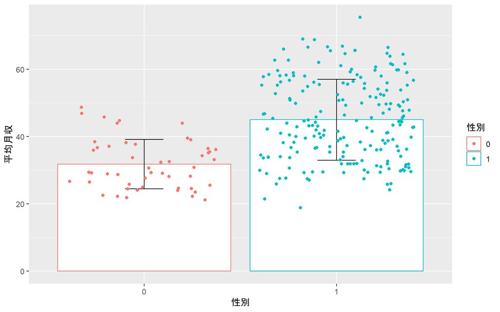

```r
data$性別 <- as.factor(data$性別)
ggplot(data, aes(x = 性別, y = 平均月収,color=性別))+
  geom_bar(stat = "summary", fun = "mean", fill = "white") +
  geom_errorbar(stat = "summary", fun.data = mean_sdl, fun.args = list(mult = 1), width = 0.2, color = "black") +
  geom_jitter(width = 0.4)
```

しかし男女差をそう単純に捉えてよいだろうか？例えば，女性の採用が始まったのが最近なのであれば，女性は若い世代が中心で給与が低く，男性の方は若手から上級管理職までいるので平均給与が高くなっているということかもしれない． したがって，より実態に即した男女差を見るためには，そうした就労期間の長さをきちんとコントロールしておく必要がある．

下図が上記の男女の比較に就労期間の情報を付与したものである．就労期間が25年を超える人では男性が女性よりもはるかに多いのがわかる．

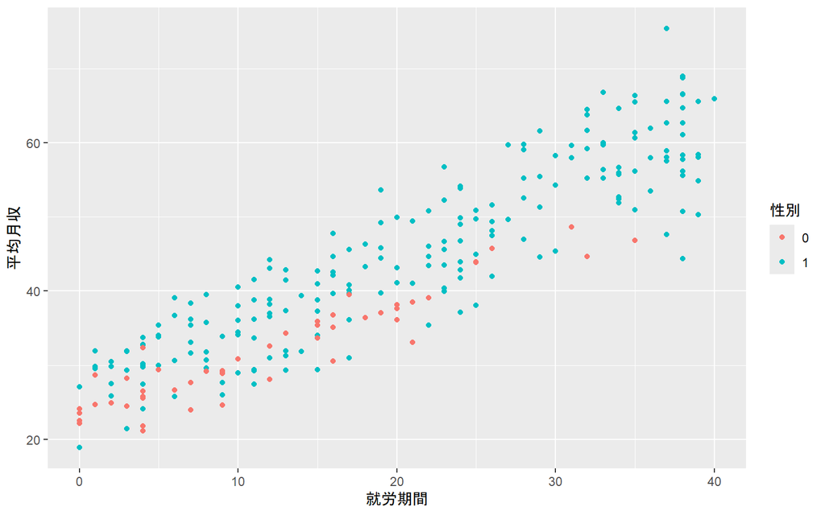

```r
data$性別 <- as.factor(data$性別)
ggplot(data, aes(x = 就労期間, y = 平均月収,color=性別)) +geom_point()
```

そこで就労期間を統制変数として投入した時の男女差は以下の通りとなる．

```r
fit<-lm(平均月収 ~ 性別 + 就労期間, data = data)
summary(fit)
```

```
##
## Call:
## lm(formula = 平均月収 ~ 性別 + 就労期間, data = data)
##
## Residuals:
##      Min       1Q   Median       3Q      Max
## -16.0538  -2.7921   0.1808   3.1131  15.8480
##
## Coefficients:
##             Estimate Std. Error t value       Pr(>|t|)
## (Intercept) 21.21182    0.75816  27.978        < 2e-16 ***
## 性別1        5.41971    0.80315   6.748 0.000000000106 ***
## 就労期間     0.88909    0.02697  32.964        < 2e-16 ***
## ---
## Signif. codes:  0 '***' 0.001 '**' 0.01 '*' 0.05 '.' 0.1 ' ' 1
##
## Residual standard error: 4.857 on 247 degrees of freedom
## Multiple R-squared:  0.8483, Adjusted R-squared:  0.847
## F-statistic: 690.4 on 2 and 247 DF,  p-value: < 2.2e-16
```

すなわち，男女で5.4万円の差がある，ということになる．先ほどよりは大分差が縮まっていることがわかる．

それでもまだ5.4万円の差がついている．これについては，残業時間に違いがあるのかもしれない．例えば子育て世代の場合，現状ではまだ多くのケースで女性が時短勤務や残業を抑えるような働き方をしているため，残業時間が少ないことが考えられる． 残業時間を男女で比較すると以下の通りとなる．

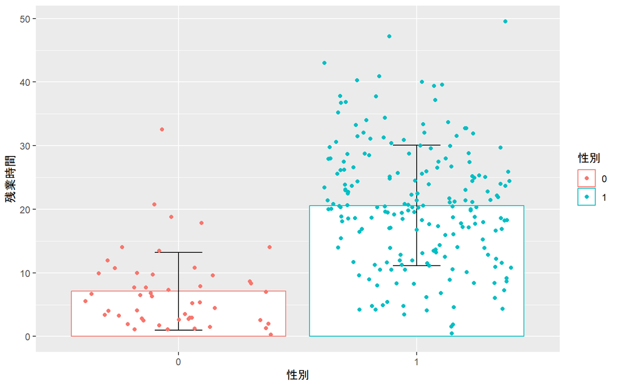

```r
ggplot(data, aes(x = 性別, y = 残業時間,color=性別)) +
  geom_bar(stat = "summary", fun = "mean", fill = "white") +
  geom_errorbar(stat = "summary", fun.data = mean_sdl, fun.args = list(mult = 1), width = 0.2, color = "black") +
  geom_jitter()
```

このように，残業時間が長いのは男性に偏っている様子が見て取れる． したがって男女の比較をするときには，残業時間も統制変数として導入しておく必要がある． その結果が最初に示した以下の結果となる．

```r
fit<-lm(平均月収 ~ 性別 + 就労期間 + 残業時間, data = data)
summary(fit)
```

```
##
## Call:
## lm(formula = 平均月収 ~ 性別 + 就労期間 + 残業時間,
##     data = data)
##
## Residuals:
##     Min      1Q  Median      3Q     Max
## -15.850  -2.272   1.201   2.777  11.009
##
## Coefficients:
##             Estimate Std. Error t value Pr(>|t|)
## (Intercept) 19.25094    0.67525  28.509   <2e-16 ***
## 性別1        1.59801    0.78703   2.030   0.0434 *
## 就労期間     0.88218    0.02295  38.442   <2e-16 ***
## 残業時間     0.28777    0.02944   9.774   <2e-16 ***
## ---
## Signif. codes:  0 '***' 0.001 '**' 0.01 '*' 0.05 '.' 0.1 ' ' 1
##
## Residual standard error: 4.13 on 246 degrees of freedom
## Multiple R-squared:  0.8907, Adjusted R-squared:  0.8894
## F-statistic: 668.3 on 3 and 246 DF,  p-value: < 2.2e-16
```

このように回帰分析にカテゴリカル変数をダミー変数に置き換えて導入し，連続変数を統制変数として投入して分析していくことで，比較する水準間の差のより真なる値を見ることができるようになる．

このように連続変数を統制しながらカテゴリカル変数の各水準間を比較していく分析のことを特に**共分散分析**と呼ぶ．

このように，カテゴリカル変数を含む回帰分析は，他の説明変数の効果をより正確に推定するというだけでなく，カテゴリカル変数の水準間の差をより正確に推定するための手法としても有用である．

# 2 交互作用を含む回帰分析

分散分析では交互作用を含んだ分析について触れたが，回帰分析においても交互作用を含んだ分析を行うことができる．

実施方法は極めて簡単で，分散分析での交互作用と同じように`:`あるいは`*`を用いて，交互作用項を含んだモデル式を作成して，`lm()`関数に投入すればよい．

以下，回帰分析における交互作用のもつ意味について説明したのち，カテゴリカル変数と連続変数の交互作用、連続変数同士の交互作用、カテゴリカル変数同士の交互作用のそれぞれについてその実施方法を説明する。

## 2.1 回帰分析における交互作用の意味

分散分析での交互作用は，カテゴリカル変数である二つの変数（要因）の相乗効果，すなわち，単純にそれぞれが単独で目的変数に対して持つ影響力の足し合わせでは説明できない，組み合わさった場合にのみ現れる新たに生じてきた影響であると解釈される．

例えば，小麦の収穫量を目的変数として，XとYという効用の異なる二つの肥料を使うケースを考えてみよう．Xだけを使ったときには使わなかったときに比べ$\varDelta X$増え，Yだけを使ったときには同様に$\varDelta Y$増えるのであれば，XとYを両方使えば収穫量は$\varDelta X + \varDelta Y$増えるだろう，と予想するのが単純な影響力の足し合わせである．しかし，実際にはXとYを組み合わせて使うと，単純な足し合わせよりも収穫量が下がってしまうことはよくある．こうした「組み合わせ」によって生じる効果が交互作用である． この例では，交互作用として目的変数に対してマイナスに作用する効果が現れる例だが，もちろんプラスに作用する効果もある．

では，回帰分析での交互作用とはどういうものだろうか．

回帰分析における交互作用を考えるときには数式を考えるとわかりやすくなる． 例えば，ある目的変数$Y$を説明するための説明変数が$X_1$と$X_2$の二つあるとする．このとき，$X_1$と$X_2$の単独の効果をそれぞれ$\beta_1$と$\beta_2$とすると，目的変数$Y$は以下のように表される．

$$y=\beta_0 + \beta_1X_1 + \beta_2X_2$$

これに交互作用項が加わり，交互作用の効果が$\beta_3$であるとすると，目的変数$Y$は以下のように表される．

$$y=\beta_0 + \beta_1X_1 + \beta_2X_2 + \beta_3X_1 \times X_2$$

この数式は以下のように変形できる．

$$\begin{align}
y=(\beta_0 + \beta_2X_2) + (\beta_1 + \beta_3X_2)X_1
\end{align}$$

このように変形すると，切片にあたる部分が$(\beta_0 + \beta_2X_2)$であり，$X_1$の回帰係数が$(\beta_1 + \beta_3X_2)$であると見ることができるようになる． このようにみると，切片にせよ，回帰係数にせよ，$X_2$の値によってその値が変わる，ということがわかる．

つまり，回帰分析での交互作用においては，**ある説明変数の目的変数に対する影響力が，他の説明変数によって変わる（調整される）**という解釈がなされる． こうしたことから回帰分析における交互作用を**調整効果**と呼ぶこともある．

## 2.2 カテゴリカル変数と連続変数の交互作用

先ほどの学歴を含めた月収データにおいて，学歴と就労年数の交互作用が平均月収にどのような影響を与えるかを調べよ．

```r
data <- read.csv("./practice/example_11_Dammy2.csv")
data$学歴<- as.factor(data$学歴)
fit_interaction <- lm(平均月収 ~ 性別 + 学歴 + 就労期間 + 残業時間 + 学歴:就労期間, data = data)
summary(fit_interaction)
```

```
##
## Call:
## lm(formula = 平均月収 ~ 性別 + 学歴 + 就労期間 +
##     残業時間 + 学歴:就労期間, data = data)
##
## Residuals:
##     Min      1Q  Median      3Q     Max
## -7.9683 -0.6875 -0.0218  0.7806  7.1298
##
## Coefficients:
##                Estimate Std. Error t value     Pr(>|t|)
## (Intercept)    15.75551    0.59423  26.514      < 2e-16 ***
## 性別           -0.40075    0.42144  -0.951     0.342605
## 学歴1           4.32672    0.67073   6.451 0.0000000006 ***
## 学歴2           7.71246    0.65536  11.768      < 2e-16 ***
## 就労期間        0.81512    0.02469  33.017      < 2e-16 ***
## 残業時間        0.29568    0.01406  21.031      < 2e-16 ***
## 学歴1:就労期間  0.04574    0.03047   1.501     0.134565
## 学歴2:就労期間  0.10386    0.02896   3.586     0.000406 ***
## ---
## Signif. codes:  0 '***' 0.001 '**' 0.01 '*' 0.05 '.' 0.1 ' ' 1
##
## Residual standard error: 1.96 on 242 degrees of freedom
## Multiple R-squared:  0.9758, Adjusted R-squared:  0.9751
## F-statistic:  1393 on 7 and 242 DF,  p-value: < 2.2e-16
```

結果を見ると，まず学歴の単独の効果として，学歴1と学歴2の回帰係数は有意であることが分かる．これは，学歴が大卒か，あるいは院卒かで平均月収の切片(Intercepts)=就労期間が0の時=初任給が高卒者と有意に異なることが分かる．

そのうえで，学歴1と就労期間の交互作用は有意ではない．つまり，学歴1が0か1かで，就労期間が目的変数に与える影響に有意な差はないということである．このことから，高卒だろうと大卒だろうと，就労期間が1年長くなるごとに平均月収は $8151$円 上がるということが分かる．すなわち，この会社では高卒と大卒で昇給のスピードは同じになっているということである．

一方，学歴2と就労期間の交互作用は有意である．つまり，院卒者は就労期間が1年伸びると平均月収がどの程度上がるかは高卒者とは有意に異なるということである．具体的には，院卒者は就労期間が1年長くなるごとに平均月収が $8151+1039=9190$円 上がる，ということであり，高卒者と比べて院卒者の方が昇給のスピードが速いということである．

**交互作用の図示**

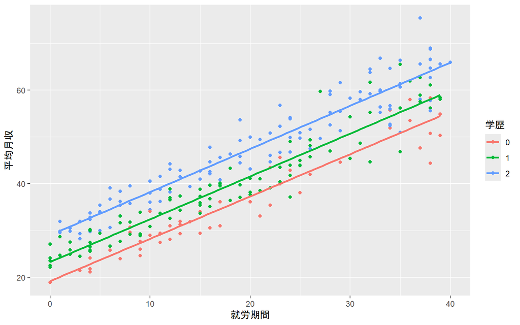

```r
library(ggplot2)
data$学歴 <- as.factor(data$学歴)
ggplot(data, aes(x = 就労期間, y = 平均月収, color = 学歴)) + geom_point() + geom_smooth(method = "lm", se = FALSE)
```

ぞれの直線を一次関数の数式で表すと以下の通りとなる．

$$\begin{align}
高卒: & 平均月収 = 157555円 +
8151 \times 就労期間 \\
大卒: & 平均月収 = (157555 + 43267)円+
8151円 \times 就労期間 \\
院卒: & 平均月収 = (157555 + 77125 )円+
(8151 + 1039 )円 \times 就労期間
\end{align}$$

先ほどの月収データにおいて，さらに学歴と残業時間の交互作用が平均月収にどのような影響を与えるかを調べ，その結果に対する解釈をテキストセルに述べよ

## 2.3 連続変数同士の交互作用

先ほどの月収データにおいて，先ほどは学歴と就労期間の交互作用を調べたが，さらに残業時間と就労期間の交互作用が平均月収にどのような影響を与えるかを調べよ．

残業時間と就労期間の交互作用なので`残業時間:就労期間`という形でモデル式に加えればよい．

```r
data <- read.csv("./practice/example_11_Dammy2.csv")
data$学歴<- as.factor(data$学歴)
fit_interaction <- lm(平均月収 ~ 性別 + 学歴 * (就労期間 + 残業時間) + 就労期間:残業時間 , data = data)
summary(fit_interaction)
```

```
##
## Call:
## lm(formula = 平均月収 ~ 性別 + 学歴 * (就労期間 +
##     残業時間) + 就労期間:残業時間, data = data)
##
## Residuals:
##     Min      1Q  Median      3Q     Max
## -8.0156 -0.5203 -0.0307  0.4228  6.4751
##
## Coefficients:
##                    Estimate Std. Error t value Pr(>|t|)
## (Intercept)       18.043394   0.676024  26.690  < 2e-16 ***
## 性別               0.063067   0.442656   0.142   0.8868
## 学歴1              3.368259   0.753139   4.472 1.20e-05 ***
## 学歴2              7.406575   0.787417   9.406  < 2e-16 ***
## 就労期間           0.709659   0.031270  22.694  < 2e-16 ***
## 残業時間           0.131581   0.031090   4.232 3.30e-05 ***
## 学歴1:就労期間     0.047666   0.029595   1.611   0.1086
## 学歴2:就労期間     0.086070   0.027673   3.110   0.0021 **
## 学歴1:残業時間     0.062925   0.032010   1.966   0.0505 .
## 学歴2:残業時間     0.044884   0.030328   1.480   0.1402
## 就労期間:残業時間  0.006008   0.001006   5.969 8.55e-09 ***
## ---
## Signif. codes:  0 '***' 0.001 '**' 0.01 '*' 0.05 '.' 0.1 ' ' 1
##
## Residual standard error: 1.821 on 239 degrees of freedom
## Multiple R-squared:  0.9794, Adjusted R-squared:  0.9785
## F-statistic:  1134 on 10 and 239 DF,  p-value: < 2.2e-16
```

この結果から，就労期間と残業時間の交互作用は有意であることが分かる．つまり，就労期間が1年長くなるごとに残業代の単価（残業時間が1時間伸びると平均月収がどれくらい上がるか）は約60円ずつ上がっていくことがわかる．

### 2.3.1 単純傾斜分析

分散分析で交互作用が有意であった場合に下位検定として単純主効果検定を行っていた．すなわち，一方の要因の水準ごとに，他方の要因の水準間での目的変数の差を検定することを行うことを行った．

これと同様のことを行うのが**単純傾斜分析（Simple Slope Analysis）**である．回帰分析において連続変数同士の交互作用が有意であった場合に，一方の説明変数を$\pm 1$標準偏差だけ変化させた場合に他方の説明変数の回帰係数が有意になるかどうかを検討する．

単純傾斜分析は`interactions`パッケージの`sim_slopes()`関数を用いることで簡単に行うことができる．例によってあらかじめ`interactions`パッケージをインストールしておくこと．

第1引数には`lm()`関数の結果のオブジェクトを，`pred`には調整を受ける側の説明変数（x軸に置きたい説明変数）を，`modx`には調整を与える側の説明変数（標準偏差を変える側の説明変数）を与える．

```r
library(interactions)
simple_slope_results <- sim_slopes(fit_interaction, pred= 残業時間, modx =就労期間 ,confint = TRUE)
print(simple_slope_results)
```

```
## JOHNSON-NEYMAN INTERVAL
##
## When 就労期間 is OUTSIDE the interval [-44.33, -9.51], the slope of
## 残業時間 is p < .05.
##
## Note: The range of observed values of 就労期間 is [0.00, 40.00]
##
## SIMPLE SLOPES ANALYSIS
##
## Slope of 残業時間 when 就労期間 =  6.940908 (- 1 SD):
##
##   Est.   S.E.   2.5%   97.5%   t val.      p
## ------ ------ ------ ------- -------- ------
##   0.17   0.03   0.12    0.23     6.34   0.00
##
## Slope of 残業時間 when 就労期間 = 18.876000 (Mean):
##
##   Est.   S.E.   2.5%   97.5%   t val.      p
## ------ ------ ------ ------- -------- ------
##   0.24   0.02   0.20    0.29    10.04   0.00
##
## Slope of 残業時間 when 就労期間 = 30.811092 (+ 1 SD):
##
##   Est.   S.E.   2.5%   97.5%   t val.      p
## ------ ------ ------ ------- -------- ------
##   0.32   0.03   0.26    0.37    11.70   0.00
```

`interactions`パッケージには，この様子を図示する`interact_plot()`関数も用意されている． 引数は先ほどと同じものを与えるが，confintは設定する必要はない．

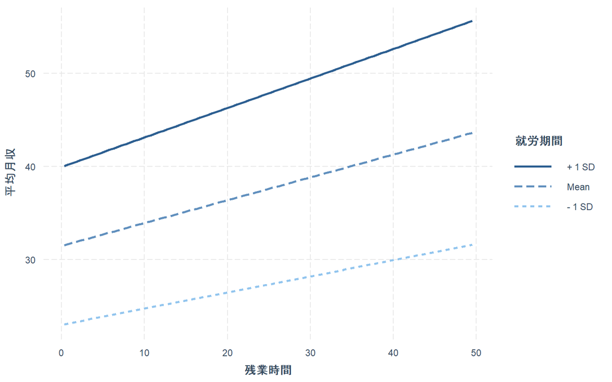

```r
interact_plot(fit_interaction, pred= 残業時間, modx =就労期間 )
```

この図から，まず切片で大きくそれぞれ差がついているが，これは就労期間が $31$年の場合， $19$年の場合， $7$年の場合のそれぞれの基本月給の差を表している．

そのうえで，就労期間が短い人に比べて就労期間が長い人は傾きが急になっており，残業代の単価が就労期間が長い人ほど高くなっていることが見てとれる．

**単純傾斜分析のマニュアル実行**

単純傾斜分析は`interactions`パッケージを用いずに，`lm()`関数だけで行うこともできる． 方法としては，標準偏差を動かしたい変数（今回であれば就労期間）に対して，**まずは平均を引いたうえで**（この処理を**中心化**と呼ぶ），1標準偏差を足す，もしくは1標準偏差を引く処理を行ったデータを用意して，それぞれに同じモデル式`lm()`に与えればよいだけである．

注意すべき点としては+1標準偏差するというのは，データを+方向に動かすのではなく，軸を+方向に動かすことを意味している．つまり，これは―1標準偏差の人たちのデータとなる． 逆に，+1標準偏差するというのは，軸を-方向に動かすことを意味しているので+1標準偏差の人たちのデータとなる．このように**処理として行った$+$，$-$と，評価対象として見ている人達がどういう人たちなのかというものが入れ替わる**ことに注意してほしい．

```r
#Sを1標準偏差足す
data_p <-data
data_p$就労期間 <- data$就労期間-mean(data$就労期間)-1*sd(data$就労期間)
fit_p<-lm(平均月収 ~ 性別 + 学歴 * (就労期間 + 残業時間) + 就労期間:残業時間 , data_p)
summary(fit_p)
```

```
##
## Call:
## lm(formula = 平均月収 ~ 性別 + 学歴 * (就労期間 +
##     残業時間) + 就労期間:残業時間, data = data_p)
##
## Residuals:
##     Min      1Q  Median      3Q     Max
## -8.0156 -0.5203 -0.0307  0.4228  6.4751
##
## Coefficients:
##                    Estimate Std. Error t value Pr(>|t|)
## (Intercept)       39.908772   0.778882  51.239  < 2e-16 ***
## 性別               0.063067   0.442656   0.142   0.8868
## 学歴1              4.836914   0.816579   5.923 1.09e-08 ***
## 学歴2             10.058485   0.794960  12.653  < 2e-16 ***
## 就労期間           0.709659   0.031270  22.694  < 2e-16 ***
## 残業時間           0.316683   0.027067  11.700  < 2e-16 ***
## 学歴1:就労期間     0.047666   0.029595   1.611   0.1086
## 学歴2:就労期間     0.086070   0.027673   3.110   0.0021 **
## 学歴1:残業時間     0.062925   0.032010   1.966   0.0505 .
## 学歴2:残業時間     0.044884   0.030328   1.480   0.1402
## 就労期間:残業時間  0.006008   0.001006   5.969 8.55e-09 ***
## ---
## Signif. codes:  0 '***' 0.001 '**' 0.01 '*' 0.05 '.' 0.1 ' ' 1
##
## Residual standard error: 1.821 on 239 degrees of freedom
## Multiple R-squared:  0.9794, Adjusted R-squared:  0.9785
## F-statistic:  1134 on 10 and 239 DF,  p-value: < 2.2e-16
```

```r
#Sを1標準偏差引く
data_m <-data
data_m$就労期間 <- data$就労期間-mean(data$就労期間)+1*sd(data$就労期間)
fit_m<-lm(平均月収 ~ 性別 + 学歴 * (就労期間 + 残業時間) + 就労期間:残業時間 , data_m)
summary(fit_m)
```

```
##
## Call:
## lm(formula = 平均月収 ~ 性別 + 学歴 * (就労期間 +
##     残業時間) + 就労期間:残業時間, data = data_m)
##
## Residuals:
##     Min      1Q  Median      3Q     Max
## -8.0156 -0.5203 -0.0307  0.4228  6.4751
##
## Coefficients:
##                    Estimate Std. Error t value Pr(>|t|)
## (Intercept)       22.969075   0.573335  40.062  < 2e-16 ***
## 性別               0.063067   0.442656   0.142   0.8868
## 学歴1              3.699108   0.666734   5.548 7.64e-08 ***
## 学歴2              8.003978   0.704157  11.367  < 2e-16 ***
## 就労期間           0.709659   0.031270  22.694  < 2e-16 ***
## 残業時間           0.173279   0.027314   6.344 1.11e-09 ***
## 学歴1:就労期間     0.047666   0.029595   1.611   0.1086
## 学歴2:就労期間     0.086070   0.027673   3.110   0.0021 **
## 学歴1:残業時間     0.062925   0.032010   1.966   0.0505 .
## 学歴2:残業時間     0.044884   0.030328   1.480   0.1402
## 就労期間:残業時間  0.006008   0.001006   5.969 8.55e-09 ***
## ---
## Signif. codes:  0 '***' 0.001 '**' 0.01 '*' 0.05 '.' 0.1 ' ' 1
##
## Residual standard error: 1.821 on 239 degrees of freedom
## Multiple R-squared:  0.9794, Adjusted R-squared:  0.9785
## F-statistic:  1134 on 10 and 239 DF,  p-value: < 2.2e-16
```

信頼区間もそれぞれ，`confint`関数を用いて求めることができる．

```r
confint(fit_p)
```

```
##                           2.5 %       97.5 %
## (Intercept)       38.3744219206 41.443122590
## 性別              -0.8089384499  0.935071622
## 学歴1              3.2283022754  6.445525762
## 学歴2              8.4924609134 11.624508690
## 就労期間           0.6480586621  0.771259958
## 残業時間           0.2633621731  0.370003929
## 学歴1:就労期間    -0.0106347398  0.105967609
## 学歴2:就労期間     0.0315558000  0.140584171
## 学歴1:残業時間    -0.0001328718  0.125982750
## 学歴2:残業時間    -0.0148616529  0.104628886
## 就労期間:残業時間  0.0040251001  0.007990211
```

```r
confint(fit_m)
```

```
##                           2.5 %       97.5 %
## (Intercept)       21.8396402093 24.098509052
## 性別              -0.8089384499  0.935071622
## 学歴1              2.3856818167  5.012533185
## 学歴2              6.6168321127  9.391124871
## 就労期間           0.6480586621  0.771259958
## 残業時間           0.1194723347  0.227086084
## 学歴1:就労期間    -0.0106347398  0.105967609
## 学歴2:就労期間     0.0315558000  0.140584171
## 学歴1:残業時間    -0.0001328718  0.125982750
## 学歴2:残業時間    -0.0148616529  0.104628886
## 就労期間:残業時間  0.0040251001  0.007990211
```

さらに，描画についても，`ggplot2`を用いて描くことができる．なお，就労期間が平均となっているケースも描画したいので，$\pm1標準偏差$にしたときと同様に就労期間で中心化し，標準偏差を足し引きはしないデータを用意して`lm()`を実行しておく．

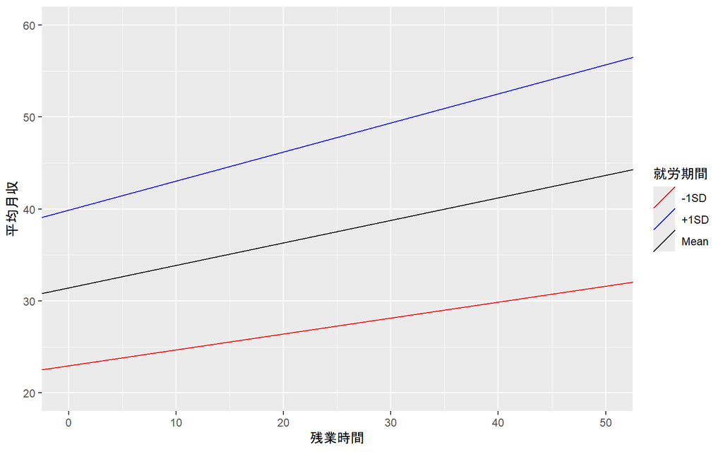

```r
data_c <-data
data_c$就労期間 <- data$就労期間-mean(data$就労期間)
fit_c<-lm(平均月収 ~ 性別 + 学歴 * (就労期間 + 残業時間) + 就労期間:残業時間 , data_c)

library(ggplot2)
ggplot(data, aes(x=残業時間, y=平均月収)) +
  geom_abline(
    aes(
      intercept = coef(fit_c)[1] ,
      slope = coef(fit_c)[6],
      color = "Mean")
    ) +
  geom_abline(
    aes(
      intercept = coef(fit_p)[1] ,
      slope = coef(fit_p)[6],
      color = "+1SD")
    )+
  geom_abline(
    aes(
      intercept = coef(fit_m)[1] ,
      slope = coef(fit_m)[6],
      color = "-1SD")
    )+
  xlim(0, 50) + ylim(20, 60)+
  scale_color_manual(values = c("+1SD" = "blue", "Mean" = "black", "-1SD" = "red")) +
  labs(color = "就労期間")
```

なお，これはあくまで学歴，性別は0の場合，すなわち高卒の女性のみのケースをグラフ化したものである．性別が男性の場合，切片が$0.06$だけ上がり（ただし，この差は有意ではない），学歴が大卒の場合は傾きが$0.06$だけ，院卒の場合は傾きが$0.04$だけ上がる．

## 2.4 カテゴリカル変数同士の交互作用

カテゴリカル変数同士の交互作用の場合は単純な分散分析となるため，`aov()`関数と`Anova()`関数の`type=3`を用いて検定を行うことができが，`aov()`関数の代わりに`lm()`関数を用いることによって，回帰分析と同じ枠組みで実施できるようになる．ただし，注意しなければならない点として，`lm()`関数の結果はあくまで**基準に対する各水準やその組み合わせの差が有意かどうか**を示すものでしかなく，**全体としてその交互作用が有意かどうか**（その交互作用項を含めることが目的変数の予測式の精度を高める上で意味があるのか）を示すものではない．したがって，`lm()`の結果を精査する前に，`Anova()`関数を用いて全体としての交互作用の有意性を示すことが必要である．

先ほどの月収データにおいて，これまでに学歴と就労期間，残業時間と就労期間の交互作用を調べてきたが，さらに学歴と性別の交互作用が平均月収にどのような影響を与えるかを調べよ．

```r
data <- read.csv("./practice/example_11_Dammy2.csv")
data$学歴<- as.factor(data$学歴)
data$性別<- as.factor(data$性別)
fit_interaction <- lm(平均月収 ~ 性別 * 学歴 + 就労期間 + 残業時間 + 就労期間:学歴 + 残業時間:就労期間, data = data)
summary(fit_interaction)
```

```
##
## Call:
## lm(formula = 平均月収 ~ 性別 * 学歴 + 就労期間 +
##     残業時間 + 就労期間:学歴 + 残業時間:就労期間,
##     data = data)
##
## Residuals:
##     Min      1Q  Median      3Q     Max
## -7.8597 -0.5344 -0.0324  0.4038  6.3761
##
## Coefficients:
##                    Estimate Std. Error t value Pr(>|t|)
## (Intercept)       17.975632   0.756772  23.753  < 2e-16 ***
## 性別1             -0.518729   0.768646  -0.675  0.50042
## 学歴1              3.638487   0.795214   4.575 7.64e-06 ***
## 学歴2              7.326736   1.479326   4.953 1.38e-06 ***
## 就労期間           0.701650   0.031087  22.570  < 2e-16 ***
## 残業時間           0.168556   0.024885   6.773 9.70e-11 ***
## 性別1:学歴1        0.911233   0.848946   1.073  0.28419
## 性別1:学歴2        0.907353   1.522934   0.596  0.55188
## 学歴1:就労期間     0.054465   0.030057   1.812  0.07123 .
## 学歴2:就労期間     0.092235   0.027851   3.312  0.00107 **
## 就労期間:残業時間  0.006069   0.001008   6.021 6.50e-09 ***
## ---
## Signif. codes:  0 '***' 0.001 '**' 0.01 '*' 0.05 '.' 0.1 ' ' 1
##
## Residual standard error: 1.832 on 239 degrees of freedom
## Multiple R-squared:  0.9791, Adjusted R-squared:  0.9782
## F-statistic:  1120 on 10 and 239 DF,  p-value: < 2.2e-16
```

結果の見方がやや面倒であるが，箇条書きにして整理すると，以下のようになる．

- まず基準は女性（性別=0），高卒（学歴=0）である．
- 学歴1の係数は$3.6$であることから，**女性・大卒**の場合は女性・高卒より月給が$3.6$万円だけ高いことがわかる．
- 学歴2の係数は$7.3$であることから，**女性・院卒**の場合は女性・高卒より月給が$7.3$万円だけ高いことがわかる．
- 性別の係数は$-0.5$であることから，**男性・高卒**の場合は女性・高卒より月給が$0.5$万円だけ低いことがわかる．ただしこの差は有意ではない．
- 性別1:学歴1の係数は$0.9$であることから，**男性・大卒**の場合は月給が$-0.5+3.6 +0.9$万円だけ高いことがわかる．
- 性別1:学歴2の係数は$0.9$であることから，**男性・院卒**の場合は月給が$-0.5+7.3 +0.9$万円だけ高いことがわかる．

ただし，冒頭で述べている通り，**このような交互作用の内容に関しての詳細な検討は，あくまで全体としての交互作用の有意性を確認してからすべきことである**． そこで，`Anova()`関数を用いて全体としての交互作用の有意性を確認する．

```r
library(car)
Anova(fit_interaction, type = 3)
```

```
## Anova Table (Type III tests)
##
## Response: 平均月収
##                    Sum Sq  Df  F value    Pr(>F)
## (Intercept)       1894.15   1 564.2067 < 2.2e-16 ***
## 性別                 1.53   1   0.4554   0.50042
## 学歴               107.26   2  15.9754 3.077e-07 ***
## 就労期間          1710.20   1 509.4149 < 2.2e-16 ***
## 残業時間           154.02   1  45.8786 9.696e-11 ***
## 性別:学歴            3.96   2   0.5891   0.55561
## 学歴:就労期間       37.86   2   5.6380   0.00405 **
## 就労期間:残業時間  121.69   1  36.2481 6.499e-09 ***
## Residuals          802.37 239
## ---
## Signif. codes:  0 '***' 0.001 '**' 0.01 '*' 0.05 '.' 0.1 ' ' 1
```

この結果から，学歴と性別の交互作用は有意ではないことがわかる． したがって，先に箇条書きで述べたような個別の水準ごとの解釈は不要であった，ということである． 今回はあくまで例題であるため，上記のような解釈を行ったが，本来は必ず解釈に先立って全体としての交互作用の有意性を確認することが重要である．

このデータは，ある会社での従業員のモチベーション（M），スキルレベル（S），業績（P）をそれぞれ評価したものである．モチベーションとスキルレベルが業績にどのような影響力持っているかを調べよ．